# 2024 Spatial Hackathon Vignette: Core Functionality

### Set-up

This vignette is to show the core functionality of our code. Our package is designed to be lightweight, and minimally dependent on other dependencies as default. For additional functionality, users may have to install relevant packages, and cross-talking with python via `reticulate`. Below are the list of dependencies:

```r
## Default requirements
require(tripack)
require(RcppML)

## Load code from repository
package_dir = 'C:/Users/kwaje/Downloads/HACKATHON/CODE/TriangulaMarkovCoLocalizer/'
funcfs <- list.files(package_dir, pattern='.R', full.names = T)
sapply(funcfs[!grepl('neighbors_250_grids', funcfs)], function(x) source(x, local = F, chdir = T))
```

```
        C:/Users/kwaje/Downloads/HACKATHON/CODE/TriangulaMarkovCoLocalizer/getGridCell.R
value   ?
visible FALSE
        C:/Users/kwaje/Downloads/HACKATHON/CODE/TriangulaMarkovCoLocalizer/getNNLatentFactors.R
value   ?
visible FALSE
        C:/Users/kwaje/Downloads/HACKATHON/CODE/TriangulaMarkovCoLocalizer/getNNMatrix.R
value   ?
visible FALSE
        C:/Users/kwaje/Downloads/HACKATHON/CODE/TriangulaMarkovCoLocalizer/heDeconvolve.R
value   ?
visible FALSE
        C:/Users/kwaje/Downloads/HACKATHON/CODE/TriangulaMarkovCoLocalizer/permutationTest.R
value   ?
visible FALSE
        C:/Users/kwaje/Downloads/HACKATHON/CODE/TriangulaMarkovCoLocalizer/tileFFTImage.R
value   ?
visible FALSE
```

```r
## Optional functionality via python
## conda create -n scipyenv python=3.9 scipy scikit-image notebook pandas
## pip install corextopic
library(reticulate)
use_python('C:/Users/kwaje/AppData/Local/anaconda3/envs/scipyenv/')
use_condaenv('scipyenv', required = TRUE)
conda_list()
```

| name | python |
| --- | --- |
| base | C:\\Users\\kwaje\\AppData\\Local\\anaconda3/python.exe |
| scipyenv | C:\\Users\\kwaje\\AppData\\Local\\anaconda3\\envs\\scipyenv/python.exe |

```r
corextopic <- import('corextopic.corextopic') ##For the CorEx model
```

Below are packages for plotting and quick data reading and manipulation. They are not compulsory for our code to run, but provide useful functionality.

```r
## Data loading
library(data.table)
library(readxl)

## Visualisation
library(ggplot2)
library(pheatmap)
library(viridis)

## Other functions
library(irlba)
```

### Getting nearest neighbours

Load the Xenium Breast Cancer dataset (Replicate 1).

```r
data_dir = 'C:/Users/kwaje/Downloads/HACKATHON/'
cell_annots <- as.data.frame(read_xlsx(paste0(data_dir, 'Cell_Barcode_Type_Matrices.xlsx'), sheet = 4))
pos_info <- fread(paste0(data_dir, 'outs/cells.csv.gz'), data.table = F)
adf <- data.frame(pos_info, 'cluster' = cell_annots[match(pos_info$cell_id, cell_annots$Barcode), 2])
adf$cluster_id <- as.integer(factor(adf$cluster))
head(adf)
```

|  | cell_id | x_centroid | y_centroid | transcript_counts | control_probe_counts | control_codeword_counts | total_counts | cell_area | nucleus_area | cluster | cluster_id |
| --- | --- | --- | --- | --- | --- | --- | --- | --- | --- | --- | --- |
| 1 | 1 | 847.2599 | 326.1914 | 28 | 1 | 0 | 29 | 58.38703 | 26.64219 | DCIS_2 | 5 |
| 2 | 2 | 826.3420 | 328.0318 | 94 | 0 | 0 | 94 | 197.01672 | 42.13078 | DCIS_2 | 5 |
| 3 | 3 | 848.7669 | 331.7432 | 9 | 0 | 0 | 9 | 16.25625 | 12.68891 | Unlabeled | 20 |
| 4 | 4 | 824.2284 | 334.2526 | 11 | 0 | 0 | 11 | 42.31141 | 10.06984 | Invasive_Tumor | 7 |
| 5 | 5 | 841.3575 | 332.2425 | 48 | 0 | 0 | 48 | 107.65250 | 37.47969 | DCIS_2 | 5 |
| 6 | 6 | 848.0222 | 336.5740 | 7 | 0 | 0 | 7 | 27.63563 | 10.38594 | Unlabeled | 20 |

```r
rm(cell_annots, pos_info)
```

A quick plot to see distribution of cell types in space. Using 2D histograms / hex is typically faster than plotting individual spots in space (thus we avoid `geom_point`).

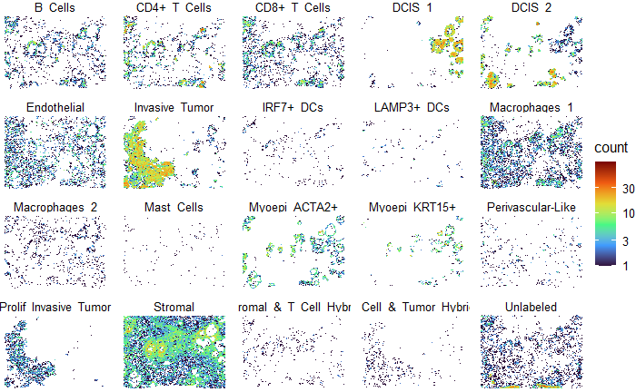

```r
ggplot(adf) +
  geom_hex(aes(x=x_centroid, y=y_centroid), bins=100) +
  scale_fill_viridis_c(option = 'turbo', trans='log10') +
  theme_void(base_size = 12) +
  facet_wrap(~cluster)
```

Below, we present our function for getting nearest neighbours per cell. This is most rapidly obtained using Delaunay triangulation (DT) - but we have also implemented a slower version using Euclidean distance cutoffs. Below, we get DT-derived 1st-3rd order neighbours to show functionality - but getting the first order neighbours is sufficient for this dataset. Note that the set of 3rd order neighbours will contain both 1st and 2nd order neighbours, as well as new neighbours.

Verbose is set to `TRUE` as default to log progress.

```r
nndf <- getNNMatrix(
  x = adf$x_centroid,
  y = adf$y_centroid,
  cell_label = adf$cluster,
  delaunayTriangulationDistanceThreshold = 20,
  delaunayNNDegrees = c(1:3),
  euclideanDistances = NULL,
  verbose = T
  )
```

```
Running delaunay triangulation approach for getting nearest neighbours...
Tabulating...
Examining neighbours of 1 degree...
Updating neighbours list with 1 order neighbours...1 of 167780...1000 of 167780...2000 of 167780...3000 of 167780...4000 of 167780...5000 of 167780...6000 of 167780...7000 of 167780...8000 of 167780...9000 of 167780...10000 of 167780...11000 of 167780...12000 of 167780...13000 of 167780...14000 of 1…
Examining neighbours of 2 degree...
Updating neighbours list with 1 order neighbours...
Updating neighbours list with 2 order neighbours...1 of 167780...1000 of 167780...2000 of 167780...3000 of 167780...4000 of 167780...5000 of 167780...6000 of 167780...7000 of 167780...8000 of 167780...9000 of 167780...10000 of 167780...11000 of 167780...12000 of 167780...13000 of 167780...14000 of 1…
Examining neighbours of 3 degree...
Updating neighbours list with 1 order neighbours...
Updating neighbours list with 2 order neighbours...
Updating neighbours list with 3 order neighbours...1 of 167780...1000 of 167780...2000 of 167780...3000 of 167780...4000 of 167780...5000 of 167780...6000 of 167780...7000 of 167780...8000 of 167780...9000 of 167780...10000 of 167780...11000 of 167780...12000 of 167780...13000 of 167780...14000 of 1…
```

What is returned is a matrix of n cells x (cell types x number of degrees or thresholds requested). In this dataset, we have 20 cell types and 167780 cells. Since the above requests to return 1st-3rd order neighbours, we have a matrix of 167780 rows and (20 x 3) columns.

```r
nndf[1:5,1:5]
```

```
     DT1_B_Cells DT1_CD4+_T_Cells DT1_CD8+_T_Cells DT1_DCIS_1 DT1_DCIS_2
[1,]           0                0                0          0          5
[2,]           0                0                0          0          5
[3,]           0                0                0          0          3
[4,]           0                0                0          0          3
[5,]           0                0                0          0          4
```

The function removes several edges: (1) convex hull, (2) edges > chosen distance. The default distance is 20 units (depends on what units are used in the x/y coordinate system), but users can reduce the distance as needed. One quick way of examining suitable distances is to sample random coordinates and see the distribution distances of the top n closest neighbours.

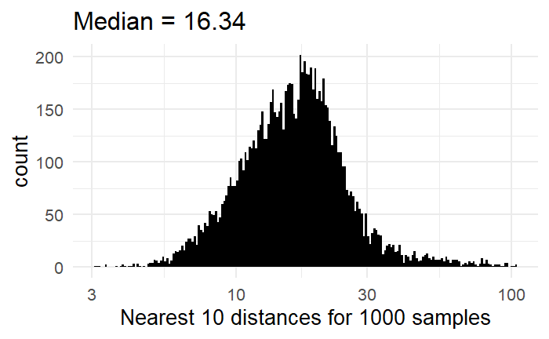

```r
set.seed(12345)
coords <- adf$x_centroid + adf$y_centroid * 1i
refs <- sample(coords, size = 1000, replace = F)
dists <- sapply(refs, function(f){
  d <- Mod(coords - f)
  d <- d[d>0]
  d <- sort(d, decreasing = F)
  d <- d[1:10]
  })
ggplot(data.frame('val' = as.vector(dists))) +
  geom_histogram(aes(x=val), fill='black', bins=200) +
  theme_minimal(base_size = 20) +
  scale_x_log10() + xlab('Nearest 10 distances for 1000 samples') +
  ggtitle(paste0('Median = ', round(median(dists), digits=2)))
```

### Permutation testing

Across the entire tissue, we might ask how often any two cell types are clustered together. Note that ‘clustered together’ can have varying meanings: e.g. we could be talking about neighbours within 10 units of Euclidean distance, or 20 units etc.

One quick way to test for significance is to use a permutation test. Below is an example to see which cell types are significantly co-localising with B cells (specifically, how often a B cell is a first order neighbour of any other cell type). We will use a one-tailed (greater) permuation test here.

```r
ref_cell_type = paste(limma::strsplit2(colnames(nndf)[1], '_')[,-1], collapse='_')
print(ref_cell_type)
```

```
[1] "B_Cells"
```

```r
nPerms = 1000
cell_labels <- adf$cluster

obs <- by(nndf[,1], cell_labels, sum)
obs <- setNames(as.numeric(obs), names(obs))

set.seed(12345)
nulldist <- list()
for(px in 1:nPerms){
  null_labs <- sample(cell_labels, size = length(cell_labels), replace = F)
  expx <- by(nndf[,1], null_labs, sum)
  expx <- setNames(as.numeric(expx), names(expx))
  nulldist[[px]] <- expx
  }
nulldist <- do.call(cbind, nulldist)
mean_exp <- rowMeans(nulldist)
sd_exp <- apply(nulldist, 1, sd)
pvals <- sapply(1:nrow(nulldist), function(j){
    pval = 1 - sum( obs[j] < nulldist[j,]) / nPerms
    pval = 1 - pval
    return(pval)
    })
```

Here, the null distributions (black) do reasonably follow a normal distribution (red). If desired, Z-scoring can be used to calculate p values - should a parametric test be desired. However, approximation to normality cannot always be guaranteed. In such cases, empirically obtained p values are more reliable (though at the cost of p values having a floor of 1 / nPerms).

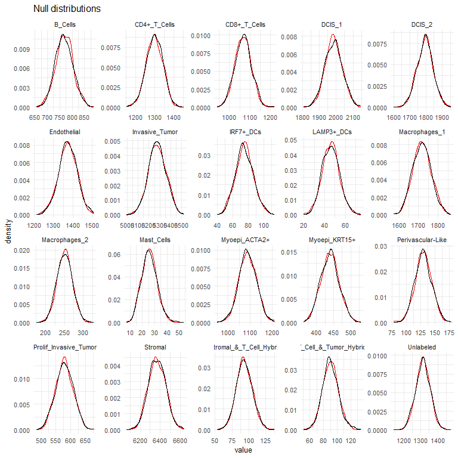

```r
set.seed(12345)
gaussian_pred <- do.call(rbind, setNames(lapply(1:nrow(nulldist), function(i){
  val <- rnorm( nPerms, mean = mean(nulldist[i,]), sd = sd(nulldist[i,]) )
  return(val)
}), rownames(nulldist)))
ggplot() +
  geom_density(data = reshape2::melt(gaussian_pred), aes(value), colour='red') +
  geom_density(data = reshape2::melt(nulldist), aes(value), colour='black') +
  theme_minimal(base_size=10) +
  facet_wrap(~Var1, scales='free') +
  ggtitle('Null distributions')
```

We see below that immune cells are those significantly clustering with B cells.

```r
print(
  data.frame(
  'OBS' = obs,
  'OBS PERCENT' = round(100 * obs / sum(obs), digits=2),
  'MEAN EXP' = mean_exp,
  'SD EXP' = sd_exp,
  'Z' = (obs - mean_exp)/sd_exp,
  'PVAL' = pvals,
  'SIG' = c('***', '**', '*', '.', '')[as.integer(cut(pvals, c(1, 0.1, 0.05, 0.01, 0.001, -1)))]
  )
)
```

|  | OBS | OBS.PERCENT | MEAN.EXP | SD.EXP | Z | PVAL | SIG |
| --- | --- | --- | --- | --- | --- | --- | --- |
| B_Cells | 4374 | 16.97 | 767.201 | 35.276154 | 102.2446792 | 0.000 | *** |
| CD4+_T_Cells | 4301 | 16.69 | 1297.633 | 43.321000 | 69.3282015 | 0.000 | *** |
| CD8+_T_Cells | 2816 | 10.92 | 1067.008 | 40.292548 | 43.4073318 | 0.000 | *** |
| DCIS_1 | 14 | 0.05 | 1985.124 | 52.744902 | -37.3708916 | 1.000 |  |
| DCIS_2 | 17 | 0.07 | 1793.797 | 49.568002 | -35.8456453 | 1.000 |  |
| Endothelial | 1053 | 4.09 | 1374.263 | 47.300266 | -6.7919914 | 1.000 |  |
| Invasive_Tumor | 328 | 1.27 | 5275.657 | 79.353893 | -62.3492659 | 1.000 |  |
| IRF7+_DCs | 291 | 1.13 | 75.104 | 11.497015 | 18.7784386 | 0.000 | *** |
| LAMP3+_DCs | 121 | 0.47 | 45.952 | 8.242186 | 9.1053514 | 0.000 | *** |
| Macrophages_1 | 2781 | 10.79 | 1716.312 | 46.795817 | 22.7517771 | 0.000 | *** |

[output cut: 10 more lines]

We have written a function to return the above table quickly.

```r
permutationTest(
  nndf[,1],
  cell_labels = adf$cluster,
  nPerms = 1000,
  verbose = F
)
```

|  | OBS | OBS.PERCENT | MEAN.EXP | SD.EXP | Z | PVAL | SIG |
| --- | --- | --- | --- | --- | --- | --- | --- |
| B_Cells | 4374 | 16.97 | 767.201 | 35.276154 | 102.2446792 | 0.000 | *** |
| CD4+_T_Cells | 4301 | 16.69 | 1297.633 | 43.321000 | 69.3282015 | 0.000 | *** |
| CD8+_T_Cells | 2816 | 10.92 | 1067.008 | 40.292548 | 43.4073318 | 0.000 | *** |
| DCIS_1 | 14 | 0.05 | 1985.124 | 52.744902 | -37.3708916 | 1.000 |  |
| DCIS_2 | 17 | 0.07 | 1793.797 | 49.568002 | -35.8456453 | 1.000 |  |
| Endothelial | 1053 | 4.09 | 1374.263 | 47.300266 | -6.7919914 | 1.000 |  |
| Invasive_Tumor | 328 | 1.27 | 5275.657 | 79.353893 | -62.3492659 | 1.000 |  |
| IRF7+_DCs | 291 | 1.13 | 75.104 | 11.497015 | 18.7784386 | 0.000 | *** |
| LAMP3+_DCs | 121 | 0.47 | 45.952 | 8.242186 | 9.1053514 | 0.000 | *** |
| Macrophages_1 | 2781 | 10.79 | 1716.312 | 46.795817 | 22.7517771 | 0.000 | *** |

[output cut: 10 more lines]

The function has also been modified to run across the entire/a subset of the nearest neighbour matrix.

```r
head(
  permutationTest(
  nndf[,1:10],
  cell_labels = adf$cluster,
  nPerms = 1000,
  verbose = F
))
```

```
[1] "Total time elapsed: 3.85223336617152"
```

|  | OBS | OBS.PERCENT | MEAN.EXP | SD.EXP | Z | PVAL | SIG | CTA | CTB |
| --- | --- | --- | --- | --- | --- | --- | --- | --- | --- |
| B_Cells | 4374 | 16.97 | 767.201 | 35.27615 | 102.244679 | 0 | *** | B_Cells | DT1_B_Cells |
| CD4+_T_Cells | 4301 | 16.69 | 1297.633 | 43.32100 | 69.328201 | 0 | *** | CD4+_T_Cells | DT1_B_Cells |
| CD8+_T_Cells | 2816 | 10.92 | 1067.008 | 40.29255 | 43.407332 | 0 | *** | CD8+_T_Cells | DT1_B_Cells |
| DCIS_1 | 14 | 0.05 | 1985.124 | 52.74490 | -37.370892 | 1 |  | DCIS_1 | DT1_B_Cells |
| DCIS_2 | 17 | 0.07 | 1793.797 | 49.56800 | -35.845645 | 1 |  | DCIS_2 | DT1_B_Cells |
| Endothelial | 1053 | 4.09 | 1374.263 | 47.30027 | -6.791991 | 1 |  | Endothelial | DT1_B_Cells |

While the above permutation test is useful for a global look at the tissue, there may be regions of the tissue that have different abundance profiles than others. To examine that further, we implemented a number of neighbourhood enrichment approaches (next section).

### Neighbourhood enrichment

Given a neighbourhood matrix, users may want to identify anatomically distinct regions. This is fundamentally a latent factor identification problem. We offer several ways to do this:

1. (Current default) Non-negative Matrix Factorisation (NMF)
2. (Requires Python) Correlation Explanation (CorEx)
3. (In progress) Hidden Markov Model (HMM)

#### NMF

For NMF, we use a very fast implementation using the `RcppML` package (a C++ implementation of the Kim and Park 2007 algorithm). To identify suitable number of factors, one quick way is to estimate using the number of Principle Components used to explain X% of variance.

As input we use log10-transformed n neighbours for convenience. Getting neighbours at multiple resolutions is also assumed to be advantageous for this purpose; hence we use the whole NN matrix (across multiple degrees).

```r
npcs = 40
pca <- irlba::prcomp_irlba(log10(1+nndf), n = npcs)
par(mfrow=c(2,1))
plot( y = 100 * (pca$sdev^2) / sum(pca$sdev^2),
      x = 1:npcs, ylab = 'VarEx (%)', xlab = 'nPCs')
plot( y = cumsum(100 * (pca$sdev^2) / sum(pca$sdev^2)),
      x = 1:npcs, ylab = 'Cum VarEx (%)', xlab = 'nPCs')
```

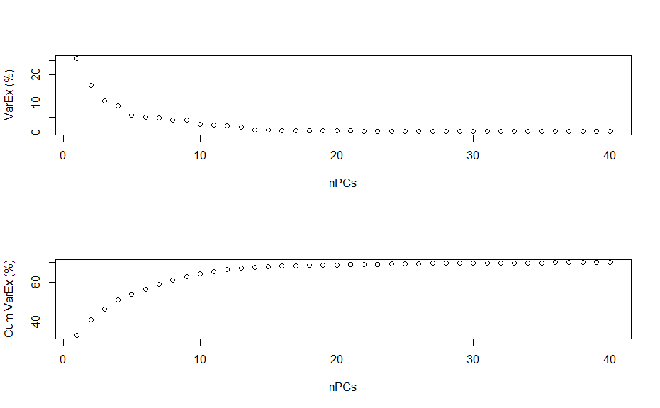

```r
par(mfrow=c(1,1))
```

Choice of k is otherwise arbitrary. One approach is maybe to pick a high value of k and then merge clusters together afterwards.

```r
latent_factors <- getNNLatentFactors(
  log10(1+nndf),
  method = 'nmf',
  k = 9,
  seed = 12345
)
```

```
Running NMF approach...
iter |      tol
---------------
   1 | 9.97e-01
   2 | 4.18e-01
   3 | 1.11e-01
   4 | 2.67e-02
   5 | 3.28e-03
   6 | 4.63e-04
   7 | 8.54e-05
Getting cell-wise loadings...Getting feature-wise loadings...
```

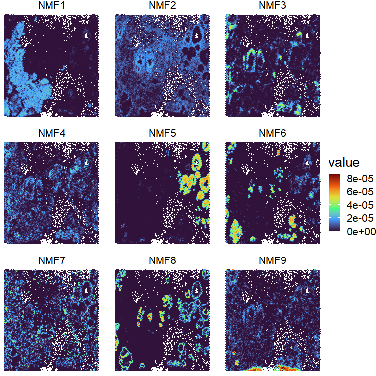

```r
w <- latent_factors$CELL_LOADINGS
if(!all(colnames(w) %in% colnames(adf))){
  adf <- cbind(adf, w)
}

ggplot( reshape2::melt(adf, measure.vars=colnames(w))) +
  stat_summary_hex(aes(x=x_centroid, y=y_centroid, z=value), fun = mean, bins=100) +
  scale_fill_viridis_c(option='turbo') +
  facet_wrap(~variable, nrow=3) +
  theme_void(base_size = 20)
```

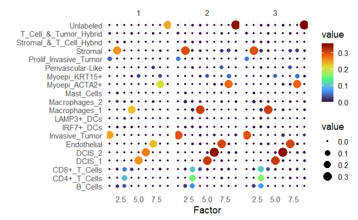

```r
h <- latent_factors$FEATURE_LOADINGS
tmp <- reshape2::melt(
  data.frame(h, 'Factor' = 1:nrow(h), check.names = F),
  id.vars = c('Factor')
  )
tmp$METHOD <- limma::strsplit2(tmp$variable, '_')[,1]
tmp$DEGREE <- as.integer(gsub('^\\D+', '', tmp$METHOD))
tmp$CT <- substr(tmp$variable, nchar(tmp$METHOD) + 2, nchar(as.character(tmp$variable)))

ggplot(tmp) +
  geom_point(aes(x=Factor, y=CT, size = value, colour=value)) +
  scale_colour_viridis_c(option='turbo') +
  theme_minimal(base_size=14) +
  facet_wrap(~DEGREE, nrow=1) +
  ylab('')
```

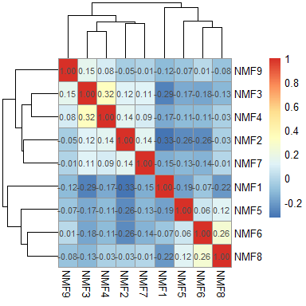

```r
pheatmap(
  cor(w), display_numbers = T
)
```

#### CorEx

CorEx is another matrix factorisation approach that uses multivariate mutual information. It is used typically in the field of topic modelling, but we have found it useful for sparse data. CorEx takes a binary (0/1) matrix and identifies groups of features that can be grouped into a latent factor. Its current implementation assumes that feature contribution per latent factor is non-overlapping (a choice borne of speed of implementation, rather than accuracy). It is thus probably most advantageous in scenarios where (1) there are a lot of cell type clusters (so that grouping these clusters into latent factors is meaningful), (2) very few cells per cell type as neighbours (amenable to binarisation).

Currently, anchoring is not supported using our function; but users can directly interface with the CorEx module for custom coding.

```r
latent_factors <- getNNLatentFactors(
  nndf,
  method = 'corex',
  k = 9,
  seed = 12345
)
```

```
Running CorEx model...Getting cell-wise loadings...Getting feature-wise loadings...
```

As before, we can see cell loadings in space. Also note that the default `w` matrix is in log probabilities, and can be exponentiated.

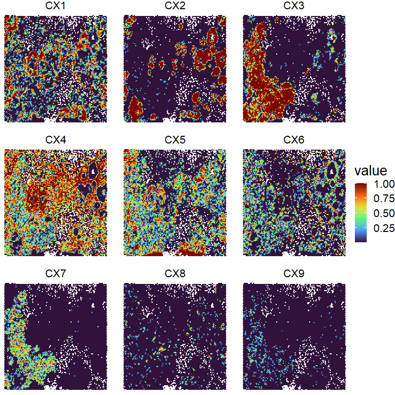

```r
w <- latent_factors$CELL_LOADINGS
if(!all(colnames(w) %in% colnames(adf))){
  adf <- cbind(adf, w)
}

ggplot( reshape2::melt(adf, measure.vars=colnames(w))) +
  stat_summary_hex(aes(x=x_centroid, y=y_centroid, z=exp(value)), fun = mean, bins=100) +
  scale_fill_viridis_c(option='turbo') +
  facet_wrap(~variable, nrow = 3) +
  theme_void(base_size = 20)
```

Note that CorEx’s feature loadings matrix is binary (0/1) - to reflect assignment of a feature to one of the n factors.

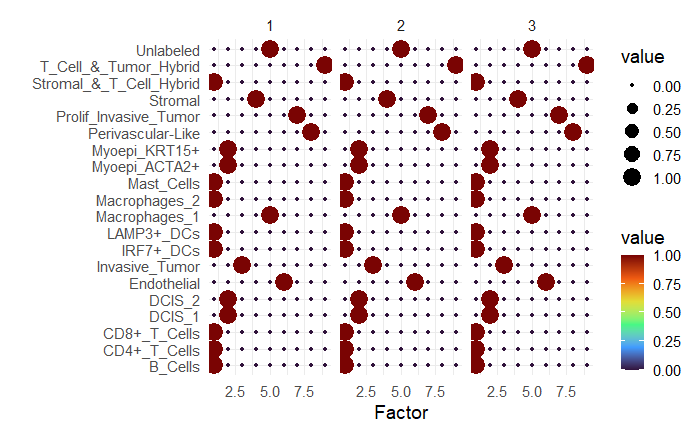

```r
h <- latent_factors$FEATURE_LOADINGS
tmp <- reshape2::melt(
  data.frame(h, 'Factor' = 1:nrow(h), check.names = F),
  id.vars = c('Factor')
  )
tmp$METHOD <- limma::strsplit2(tmp$variable, '_')[,1]
tmp$DEGREE <- as.integer(gsub('^\\D+', '', tmp$METHOD))
tmp$CT <- substr(tmp$variable, nchar(tmp$METHOD) + 2, nchar(as.character(tmp$variable)))

ggplot(tmp) +
  geom_point(aes(x=Factor, y=CT, size = value, colour=value)) +
  scale_colour_viridis_c(option='turbo') +
  theme_minimal(base_size=14) +
  facet_wrap(~DEGREE, nrow=1) +
  ylab('')
```

As before, we can ask if any clusters are redundant.

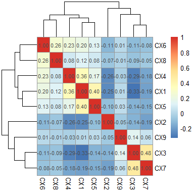

```r
pheatmap(
  cor(exp(w)), display_numbers = T
)
```

#### HMM

We are currently developing a Hidden Markov Model for neighbourhood enrichment. We suspect this model may provide added sensitivity compared to the above options. This model will be given its own vignette.